# Sujet-2_Peer-review

ENGELS Loïc

2023-11-09

# Sujet 2 : le pouvoir d’achat des ouvriers anglais du XVIe au XIXe siècle

A few remarks for understanding the data: - Until 1971, the pound sterling was divided into 20 shillings, and a shilling into 12 pence. - The wheat price is given in shillings per quarter, a quarter being 15 British pounds or about 6,8 kg. - Salaries are given in shillings per week.

```r
library(ggplot2)
library(dplyr)
library(tidyr)
library(grid)
library(gridExtra)
```

## Step 1 : Reproduce the graph of Payfair from the numerical data

We gonna take a first look to the data

```r
data = read.csv("Wheat.csv", header = TRUE)
data
```

```
##    rownames Year Wheat Wages
## 1         1 1565  41.0  5.00
## 2         2 1570  45.0  5.05
## 3         3 1575  42.0  5.08
## 4         4 1580  49.0  5.12
## 5         5 1585  41.5  5.15
## 6         6 1590  47.0  5.25
## 7         7 1595  64.0  5.54
## 8         8 1600  27.0  5.61
## 9         9 1605  33.0  5.69
## 10       10 1610  32.0  5.78
## 11       11 1615  33.0  5.94
## 12       12 1620  35.0  6.01
## 13       13 1625  33.0  6.12
## 14       14 1630  45.0  6.22
```

[output cut: 39 more lines]

Let’s check if we have any missing inforamtion in those data

```r
na_records = apply(data, 1, function (x) any(is.na(x)))
data[na_records,]
```

```
##    rownames Year Wheat Wages
## 51       51 1815    78    NA
## 52       52 1820    54    NA
## 53       53 1821    54    NA
```

We have the last three row of the data set were information about Wages are missing We need to be aware of that if we want to make any conclusion about this graph

Actually remove those three line will help us to see clearly the evoltuion without making mistakes

```r
rows_to_remove <- c(51, 52, 53)
data <- data[-rows_to_remove, ]
tail(data)
```

```
##    rownames Year Wheat Wages
## 45       45 1785  42.0  23.0
## 46       46 1790  47.5  25.5
## 47       47 1795  76.0  27.5
## 48       48 1800  79.0  28.5
## 49       49 1805  81.0  29.5
## 50       50 1810  99.0  30.0
```

Know we want to plot the graphics to reproduce the Payfair’s graph

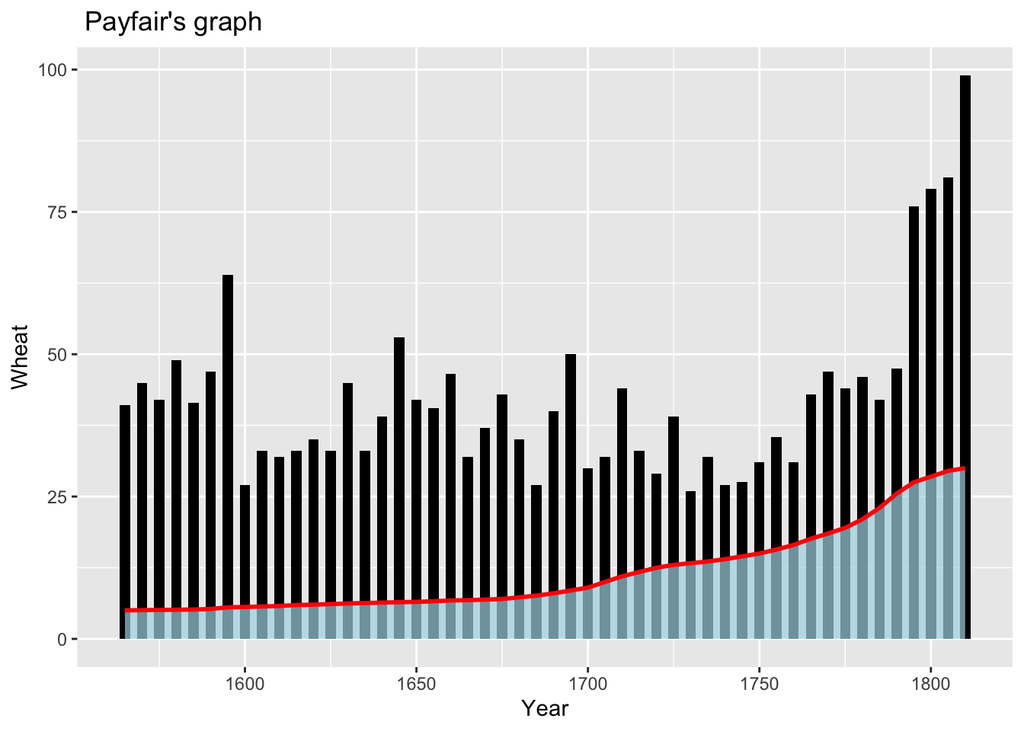

```r
ggplot(data = data, aes(x = Year)) +
  geom_bar(aes(y = Wheat), stat = "identity", width = 3, fill = "black") +
  geom_ribbon(aes(ymin = 0, ymax = Wages), fill = "lightblue", alpha = 0.7) +
  geom_line(aes(y = Wages), color = "red", size = 1) +
  labs(title = " Payfair's graph")
```

## Stet 2 : Have a different y axis on the right for the Wheat and on the left for the Wages

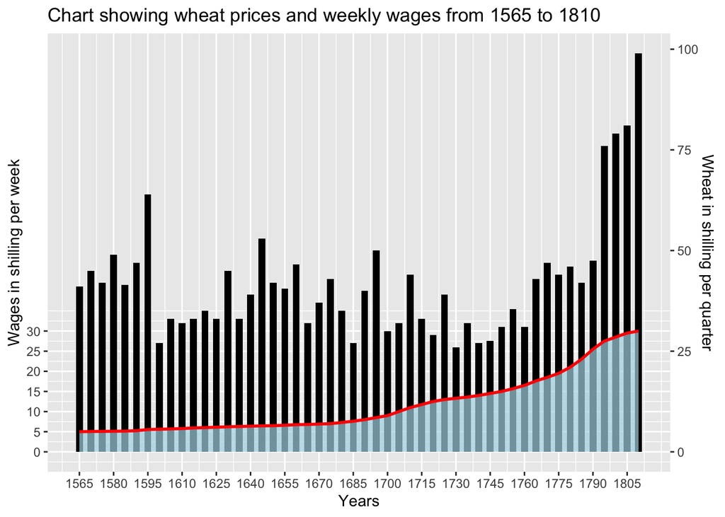

```r
ggplot(data = data, aes(x = Year)) +
  geom_bar(aes(y = Wheat), stat = "identity", width = 3, fill = "black") +
  geom_ribbon(aes(ymin = 0, ymax = Wages), fill = "lightblue", alpha = 0.7) +
  geom_line(aes(y = Wages), color = "red", size = 1) +
  scale_y_continuous(
    name = "Wages in shilling per week",
    breaks = seq(0, max(data$Wages), by = 5),
    sec.axis = sec_axis(~.*1, name = "Wheat in shilling per quarter")
  ) +
  scale_x_continuous("Years", breaks = seq(min(data$Year), max(data$Year), by=15)) +
  labs(title = "Chart showing wheat prices and weekly wages from 1565 to 1810")
```

We can have an other representation for the curve and shaded surface. To improve the visualisation we can have two barplot

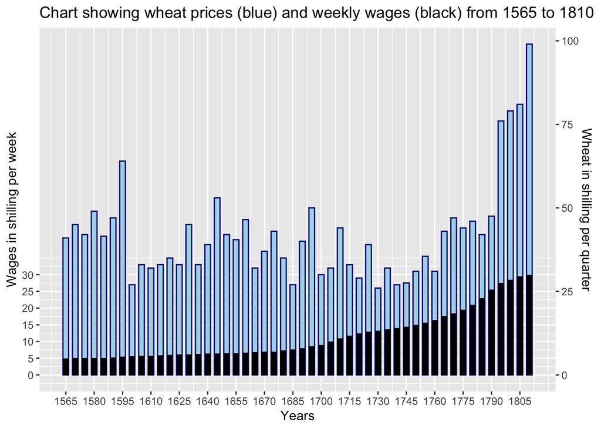

```r
ggplot(data = data, aes(x = Year)) +
  geom_bar(aes(y = Wheat), stat = "identity", width = 3, fill = "lightblue", color = "darkblue") +
  geom_bar(aes(y = Wages), stat = "identity", width = 3, fill = "black") +
  scale_y_continuous(
    name = "Wages in shilling per week",
    breaks = seq(0, max(data$Wages), by = 5),
    sec.axis = sec_axis(~.*1, name = "Wheat in shilling per quarter")
  ) +
  scale_x_continuous("Years", breaks = seq(min(data$Year), max(data$Year), by=15)) +
  labs(title = "Chart showing wheat prices (blue) and weekly wages (black) from 1565 to 1810")
```

## Step 3 Plot of the workers’ purchasing power

We want here to plot the purchasing power of worker. To do that we will plot a curve showing the amount of wheat a worker can buy with a weekly salary over time

We fisrt will create a new colon corresponding to the division of Wages by Wheat to have the purchasing power of worker

```r
data$Power <- data$Wages / data$Wheat
data
```

```
##    rownames Year Wheat Wages     Power
## 1         1 1565  41.0  5.00 0.1219512
## 2         2 1570  45.0  5.05 0.1122222
## 3         3 1575  42.0  5.08 0.1209524
## 4         4 1580  49.0  5.12 0.1044898
## 5         5 1585  41.5  5.15 0.1240964
## 6         6 1590  47.0  5.25 0.1117021
## 7         7 1595  64.0  5.54 0.0865625
## 8         8 1600  27.0  5.61 0.2077778
## 9         9 1605  33.0  5.69 0.1724242
## 10       10 1610  32.0  5.78 0.1806250
## 11       11 1615  33.0  5.94 0.1800000
## 12       12 1620  35.0  6.01 0.1717143
## 13       13 1625  33.0  6.12 0.1854545
## 14       14 1630  45.0  6.22 0.1382222
```

[output cut: 36 more lines]

To have a better visualization we will multiply the data by 10

```r
data$Power <- data$Power * 10
data
```

```
##    rownames Year Wheat Wages    Power
## 1         1 1565  41.0  5.00 1.219512
## 2         2 1570  45.0  5.05 1.122222
## 3         3 1575  42.0  5.08 1.209524
## 4         4 1580  49.0  5.12 1.044898
## 5         5 1585  41.5  5.15 1.240964
## 6         6 1590  47.0  5.25 1.117021
## 7         7 1595  64.0  5.54 0.865625
## 8         8 1600  27.0  5.61 2.077778
## 9         9 1605  33.0  5.69 1.724242
## 10       10 1610  32.0  5.78 1.806250
## 11       11 1615  33.0  5.94 1.800000
## 12       12 1620  35.0  6.01 1.717143
## 13       13 1625  33.0  6.12 1.854545
## 14       14 1630  45.0  6.22 1.382222
```

[output cut: 36 more lines]

Now we can plot the graph

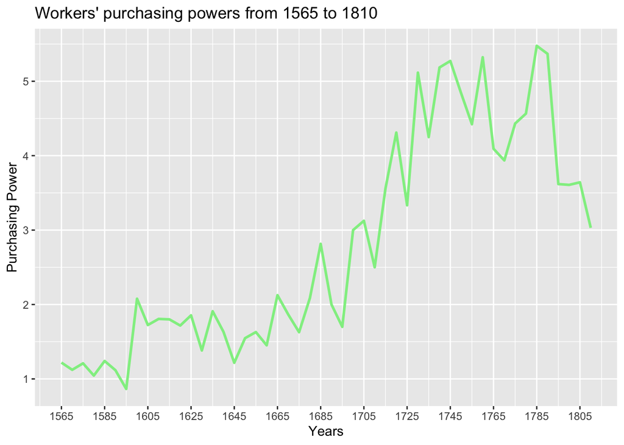

```r
ggplot(data = data, aes(x = Year)) +
  geom_line(aes(y = Power), color = "lightgreen" , size = 1) +
  scale_y_continuous("Purchasing Power") +
  scale_x_continuous("Years", breaks = seq(min(data$Year), max(data$Year), by=20)) +
  labs(title = "Workers' purchasing powers from 1565 to 1810")
```

We know want to plot both quantities Wheat and Wages on two different axis to be able of see clearly differences

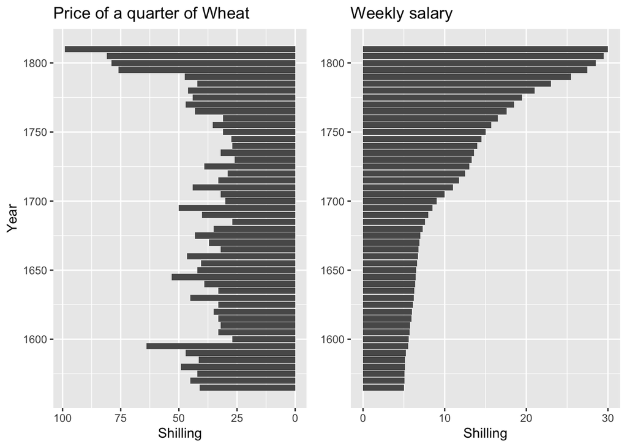

```r
gWheat <- ggplot(data = data, aes(x=Year)) +
            geom_bar(aes(y = Wheat), stat = "identity") +
            ggtitle("Price of a quarter of Wheat") +
            scale_y_reverse() +
            ylab("Shilling") +
            coord_flip()

gWages <- ggplot(data = data, aes(x=Year)) +
            geom_bar(aes(y = Wages), stat = "identity") +
            xlab(NULL) +
            ylab("Shilling") +
            ggtitle("Weekly salary") +
            coord_flip()



gg1 <- ggplot_gtable(ggplot_build(gWheat))
gg2 <- ggplot_gtable(ggplot_build(gWages))

grid.arrange(gg1,gg2,ncol=2,widths=c(1/2,1/2))
```

## Step 4 Conclusion

During this subject I explore a lot of different possibility to print some data. Overall I would prefer to represent data on a same bar plot to ba able to compare them easily since we have the same scale. And to add a plot after that to illustrate more precisely the point that we want to highlight. Sometimes we need to have to different ordinates axes to visualize the data, in this specific case we need to be careful of the scale.